# Survival Analysis of Diabetes Incidence

Lauren Bastian

11/13/22

# Study of Women’s Health Across the Nation

The data come from the Study of Women’s Health Across the Nation (SWAN), a longitudinal population-based study of 3302 middle-aged women with data collected between 1998 and 2008, with data made public for research purposes through [ICPSR](https://www.icpsr.umich.edu/web/ICPSR/series/00253). The analytical sample contains 2686 records of middle-aged women who participated in the study and had complete observations for race, baseline BMI, baseline household income, and health insurance. Race, household income, and insurance status were assessed during a baseline visit and are assumed to be indicative of race, household income, and insurance status throughout the study. Diabetes status was assessed during baseline as whether or not the individual was currently treating diabetes using insulin, and explicitly assessed during ten follow-up visits ($t$ is the years since baseline visit).

# Research Objectives

How does insurance status affect the onset of diabetes among middle-aged American women over 10 years? Does this affect remain after controlling for race and household income, BMI, and age group?

How do race and income affect onset of diabetes among middle-aged American women? Does the affect of race on diabetes onset remain after controlling for household income, BMI, and age group?

How does yearly household income, BMI, race, and insurance affect the onset of diabetes among the middle-aged American women? Are there any interactions between these factors?

# Descriptive Statistics

Histogram of time to event for uncensored individuals. Time to event is left skewed with a peak at 10 years.

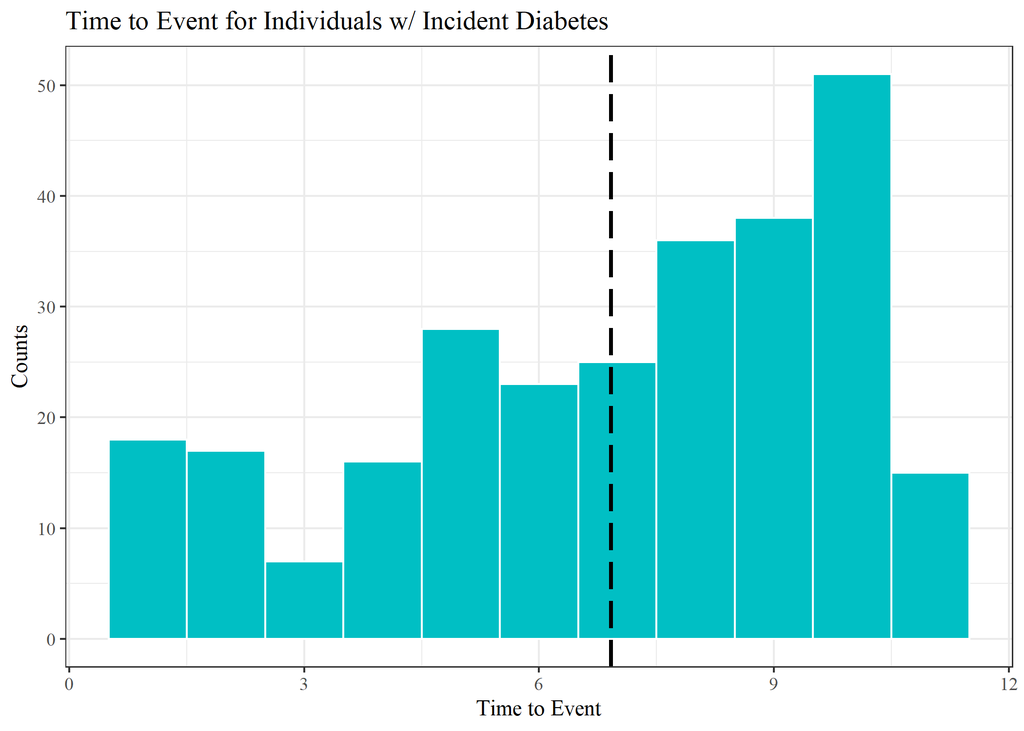

```
## [1] 6.916058
```

```
## [1] 2.933368
```

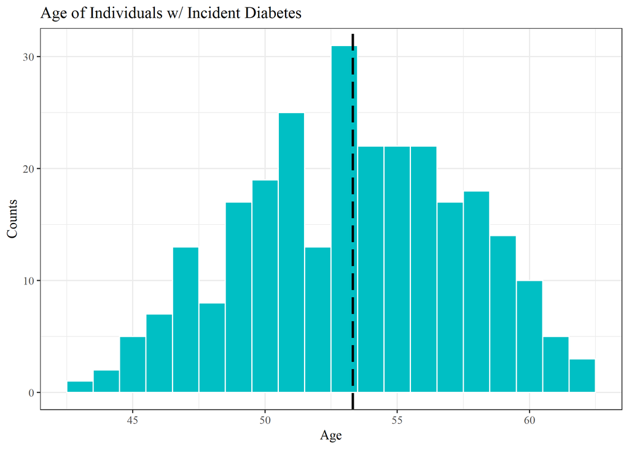

```
## [1] 53.32117
```

```
## [1] 4.152645
```

```
##                                surv.df$event
## surv.df$race                       0    1
##   Black/African American         561  115
##   Chinese/Chinese American       214   19
##   Japanese/Japanese American     224   19
##   Non-Hispanic White/Caucausian 1238  101
##   Hispanic                       175   20
```

```
##                  surv.df$event
## surv.df$bmi_group    0    1
##             <30   1765   95
##             30_40  525  115
##             40+    122   64
```

```
##                surv.df$event
## surv.df$insured    0    1
##             No   143   28
##             Yes 2269  246
```

```
##               surv.df$event
## surv.df$income   0   1
##          <20   273  65
##          20-49 791 106
##          50-99 938  87
##          100+  410  16
```

```
##                  surv.df$event
## surv.df$age_group    0    1
##             42_45 1159  116
##             46_49 1005  112
##             50_53  248   46
```

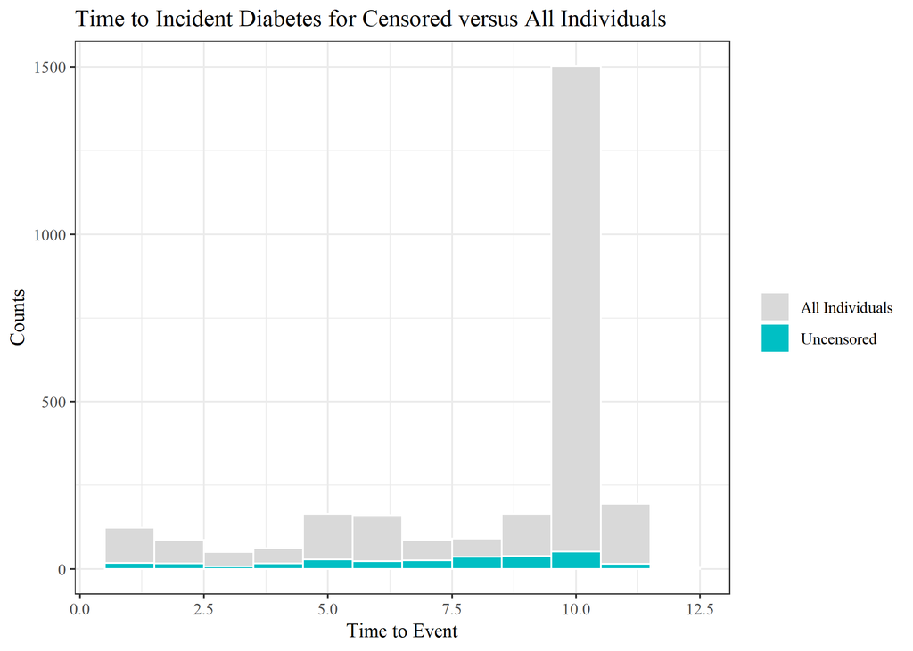

The mean age at $t = 0$ is 45.899.

```
## [1] 45.89911
```

Count distribution of the age group upon study entry. This will be our age strata.

```
##
## 42_45 46_49 50_53
##  1275  1117   294
```

Count distribution of insurance status at baseline. There are 171 uninsured and 2515 insured women in the study.

```
##
##   No  Yes
##  171 2515
```

6.37% of women in the study are uninsured at baseline.

```
## [1] 0.06366344
```

Race counts of the analytical sample ($n = 2686$)

```
##
##        Black/African American      Chinese/Chinese American
##                           676                           233
##    Japanese/Japanese American Non-Hispanic White/Caucausian
##                           243                          1339
##                      Hispanic
##                           195
```

Distribution of self-reported household income at baseline.

```
##
##   <20 20-49 50-99  100+
##   338   897  1025   426
```

Histogram of continuous BMI. BMI group cutoff points are indicated by vertical dashed lines.

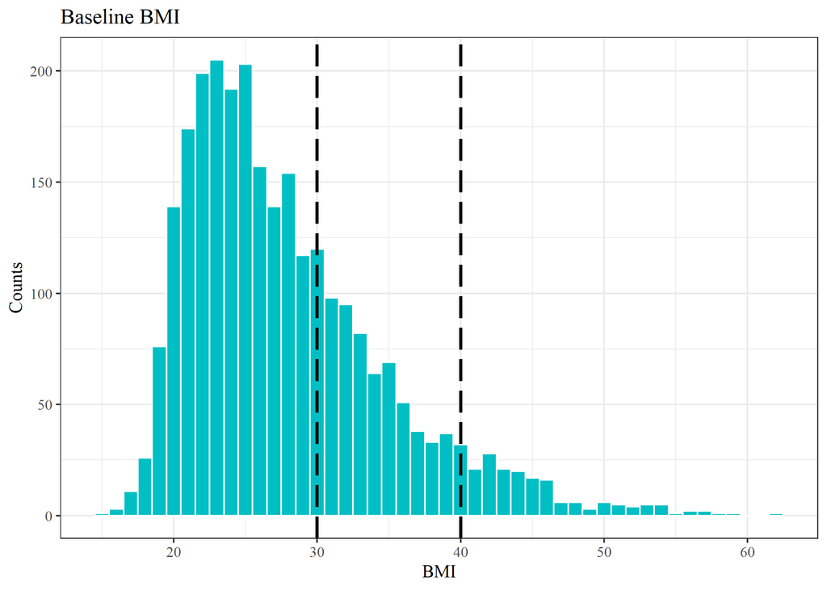

Distribution of BMI groups. There are 186 women in the highest BMI group.

```
##
##   <30 30_40   40+
##  1860   640   186
```

Incident diabetes counts over the course of the study. 274 participants out of 2686 developed diabetes during the course of the study, 11.36% of the analytical sample.

```
##
##    0    1
## 2412  274
```

```
## [1] 0.1135987
```

# Exploratory Analysis

Cross tabulation for insurance and income.

```
##         income  <20 20-49 50-99 100+
## insured
## No              104    52    13    2
## Yes             234   845  1012  424
```

```
##
##    Cell Contents
## |-------------------------|
## |                   Count |
## |             Row Percent |
## |          Column Percent |
## |           Total Percent |
## |-------------------------|
##
## Total Observations in Table:  2686
##
##                 | surv.df$income
## surv.df$insured |      <20  |    20-49  |    50-99  |     100+  | Row Total |
## ----------------|-----------|-----------|-----------|-----------|-----------|
##              No |      104  |       52  |       13  |        2  |      171  |
##                 |    60.82% |    30.41% |     7.60% |     1.17% |     6.37% |
##                 |    30.77% |     5.80% |     1.27% |     0.47% |           |
##                 |     3.87% |     1.94% |     0.48% |     0.07% |           |
## ----------------|-----------|-----------|-----------|-----------|-----------|
##             Yes |      234  |      845  |     1012  |      424  |     2515  |
##                 |     9.30% |    33.60% |    40.24% |    16.86% |    93.63% |
##                 |    69.23% |    94.20% |    98.73% |    99.53% |           |
##                 |     8.71% |    31.46% |    37.68% |    15.79% |           |
## ----------------|-----------|-----------|-----------|-----------|-----------|
##    Column Total |      338  |      897  |     1025  |      426  |     2686  |
##                 |    12.58% |    33.40% |    38.16% |    15.86% |           |
## ----------------|-----------|-----------|-----------|-----------|-----------|
##
##
```

Cross tabulation for income and BMI.

```
##           income <20 20-49 50-99 100+
## bmi_group
## <30              177   582   737  364
## 30_40            116   243   226   55
## 40+               45    72    62    7
```

```
##
##    Cell Contents
## |-------------------------|
## |                   Count |
## |             Row Percent |
## |          Column Percent |
## |           Total Percent |
## |-------------------------|
##
## Total Observations in Table:  2686
##
##                   | surv.df$income
## surv.df$bmi_group |      <20  |    20-49  |    50-99  |     100+  | Row Total |
## ------------------|-----------|-----------|-----------|-----------|-----------|
##               <30 |      177  |      582  |      737  |      364  |     1860  |
##                   |     9.52% |    31.29% |    39.62% |    19.57% |    69.25% |
##                   |    52.37% |    64.88% |    71.90% |    85.45% |           |
##                   |     6.59% |    21.67% |    27.44% |    13.55% |           |
## ------------------|-----------|-----------|-----------|-----------|-----------|
##             30_40 |      116  |      243  |      226  |       55  |      640  |
##                   |    18.12% |    37.97% |    35.31% |     8.59% |    23.83% |
##                   |    34.32% |    27.09% |    22.05% |    12.91% |           |
##                   |     4.32% |     9.05% |     8.41% |     2.05% |           |
## ------------------|-----------|-----------|-----------|-----------|-----------|
##               40+ |       45  |       72  |       62  |        7  |      186  |
##                   |    24.19% |    38.71% |    33.33% |     3.76% |     6.92% |
##                   |    13.31% |     8.03% |     6.05% |     1.64% |           |
##                   |     1.68% |     2.68% |     2.31% |     0.26% |           |
## ------------------|-----------|-----------|-----------|-----------|-----------|
##      Column Total |      338  |      897  |     1025  |      426  |     2686  |
##                   |    12.58% |    33.40% |    38.16% |    15.86% |           |
## ------------------|-----------|-----------|-----------|-----------|-----------|
##
##
```

Cross tabulation for race and income.

```
##                               income <20 20-49 50-99 100+
## race
## Black/African American               129   277   221   49
## Chinese/Chinese American              11    81    93   48
## Japanese/Japanese American             7    52   114   70
## Non-Hispanic White/Caucausian         81   422   582  254
## Hispanic                             110    65    15    5
```

```
##
##    Cell Contents
## |-------------------------|
## |                   Count |
## |             Row Percent |
## |          Column Percent |
## |           Total Percent |
## |-------------------------|
##
## Total Observations in Table:  2686
##
##                               | surv.df$income
##                  surv.df$race |      <20  |    20-49  |    50-99  |     100+  | Row Total |
## ------------------------------|-----------|-----------|-----------|-----------|-----------|
##        Black/African American |      129  |      277  |      221  |       49  |      676  |
##                               |    19.08% |    40.98% |    32.69% |     7.25% |    25.17% |
##                               |    38.17% |    30.88% |    21.56% |    11.50% |           |
##                               |     4.80% |    10.31% |     8.23% |     1.82% |           |
## ------------------------------|-----------|-----------|-----------|-----------|-----------|
##      Chinese/Chinese American |       11  |       81  |       93  |       48  |      233  |
##                               |     4.72% |    34.76% |    39.91% |    20.60% |     8.67% |
##                               |     3.25% |     9.03% |     9.07% |    11.27% |           |
##                               |     0.41% |     3.02% |     3.46% |     1.79% |           |
## ------------------------------|-----------|-----------|-----------|-----------|-----------|
##    Japanese/Japanese American |        7  |       52  |      114  |       70  |      243  |
##                               |     2.88% |    21.40% |    46.91% |    28.81% |     9.05% |
##                               |     2.07% |     5.80% |    11.12% |    16.43% |           |
##                               |     0.26% |     1.94% |     4.24% |     2.61% |           |
## ------------------------------|-----------|-----------|-----------|-----------|-----------|
## Non-Hispanic White/Caucausian |       81  |      422  |      582  |      254  |     1339  |
##                               |     6.05% |    31.52% |    43.47% |    18.97% |    49.85% |
##                               |    23.96% |    47.05% |    56.78% |    59.62% |           |
##                               |     3.02% |    15.71% |    21.67% |     9.46% |           |
## ------------------------------|-----------|-----------|-----------|-----------|-----------|
##                      Hispanic |      110  |       65  |       15  |        5  |      195  |
##                               |    56.41% |    33.33% |     7.69% |     2.56% |     7.26% |
##                               |    32.54% |     7.25% |     1.46% |     1.17% |           |
##                               |     4.10% |     2.42% |     0.56% |     0.19% |           |
## ------------------------------|-----------|-----------|-----------|-----------|-----------|
##                  Column Total |      338  |      897  |     1025  |      426  |     2686  |
##                               |    12.58% |    33.40% |    38.16% |    15.86% |           |
## ------------------------------|-----------|-----------|-----------|-----------|-----------|
##
##
```

Cross tabulation for race and insurance status.

```
##                               insured   No  Yes
## race
## Black/African American                  37  639
## Chinese/Chinese American                 0  233
## Japanese/Japanese American               5  238
## Non-Hispanic White/Caucausian           54 1285
## Hispanic                                75  120
```

```
##
##    Cell Contents
## |-------------------------|
## |                   Count |
## |             Row Percent |
## |          Column Percent |
## |           Total Percent |
## |-------------------------|
##
## Total Observations in Table:  2686
##
##                               | surv.df$insured
##                  surv.df$race |       No  |      Yes  | Row Total |
## ------------------------------|-----------|-----------|-----------|
##        Black/African American |       37  |      639  |      676  |
##                               |     5.47% |    94.53% |    25.17% |
##                               |    21.64% |    25.41% |           |
##                               |     1.38% |    23.79% |           |
## ------------------------------|-----------|-----------|-----------|
##      Chinese/Chinese American |        0  |      233  |      233  |
##                               |     0.00% |   100.00% |     8.67% |
##                               |     0.00% |     9.26% |           |
##                               |     0.00% |     8.67% |           |
## ------------------------------|-----------|-----------|-----------|
##    Japanese/Japanese American |        5  |      238  |      243  |
##                               |     2.06% |    97.94% |     9.05% |
##                               |     2.92% |     9.46% |           |
##                               |     0.19% |     8.86% |           |
## ------------------------------|-----------|-----------|-----------|
## Non-Hispanic White/Caucausian |       54  |     1285  |     1339  |
##                               |     4.03% |    95.97% |    49.85% |
##                               |    31.58% |    51.09% |           |
##                               |     2.01% |    47.84% |           |
## ------------------------------|-----------|-----------|-----------|
##                      Hispanic |       75  |      120  |      195  |
##                               |    38.46% |    61.54% |     7.26% |
##                               |    43.86% |     4.77% |           |
##                               |     2.79% |     4.47% |           |
## ------------------------------|-----------|-----------|-----------|
##                  Column Total |      171  |     2515  |     2686  |
##                               |     6.37% |    93.63% |           |
## ------------------------------|-----------|-----------|-----------|
##
##
```

Cross tabulation for BMI and race.

```
##                               bmi_group <30 30_40 40+
## race
## Black/African American                  339   253  84
## Chinese/Chinese American                224     7   2
## Japanese/Japanese American              231    11   1
## Non-Hispanic White/Caucausian           939   317  83
## Hispanic                                127    52  16
```

```
##
##    Cell Contents
## |-------------------------|
## |                   Count |
## |             Row Percent |
## |          Column Percent |
## |           Total Percent |
## |-------------------------|
##
## Total Observations in Table:  2686
##
##                               | surv.df$bmi_group
##                  surv.df$race |      <30  |    30_40  |      40+  | Row Total |
## ------------------------------|-----------|-----------|-----------|-----------|
##        Black/African American |      339  |      253  |       84  |      676  |
##                               |    50.15% |    37.43% |    12.43% |    25.17% |
##                               |    18.23% |    39.53% |    45.16% |           |
##                               |    12.62% |     9.42% |     3.13% |           |
## ------------------------------|-----------|-----------|-----------|-----------|
##      Chinese/Chinese American |      224  |        7  |        2  |      233  |
##                               |    96.14% |     3.00% |     0.86% |     8.67% |
##                               |    12.04% |     1.09% |     1.08% |           |
##                               |     8.34% |     0.26% |     0.07% |           |
## ------------------------------|-----------|-----------|-----------|-----------|
##    Japanese/Japanese American |      231  |       11  |        1  |      243  |
##                               |    95.06% |     4.53% |     0.41% |     9.05% |
##                               |    12.42% |     1.72% |     0.54% |           |
##                               |     8.60% |     0.41% |     0.04% |           |
## ------------------------------|-----------|-----------|-----------|-----------|
## Non-Hispanic White/Caucausian |      939  |      317  |       83  |     1339  |
##                               |    70.13% |    23.67% |     6.20% |    49.85% |
##                               |    50.48% |    49.53% |    44.62% |           |
##                               |    34.96% |    11.80% |     3.09% |           |
## ------------------------------|-----------|-----------|-----------|-----------|
##                      Hispanic |      127  |       52  |       16  |      195  |
##                               |    65.13% |    26.67% |     8.21% |     7.26% |
##                               |     6.83% |     8.12% |     8.60% |           |
##                               |     4.73% |     1.94% |     0.60% |           |
## ------------------------------|-----------|-----------|-----------|-----------|
##                  Column Total |     1860  |      640  |      186  |     2686  |
##                               |    69.25% |    23.83% |     6.92% |           |
## ------------------------------|-----------|-----------|-----------|-----------|
##
##
```

Incident diabetes by race.

```
##                                event
## race                               0    1
##   Black/African American         561  115
##   Chinese/Chinese American       214   19
##   Japanese/Japanese American     224   19
##   Non-Hispanic White/Caucausian 1238  101
##   Hispanic                       175   20
```

Incident diabetes by insurance status.

```
##        event
## insured    0    1
##     No   143   28
##     Yes 2269  246
```

Incident diabetes by household income at baseline.

```
##        event
## income    0   1
##   <20   273  65
##   20-49 791 106
##   50-99 938  87
##   100+  410  16
```

Incident diabetes by baseline BMI group status.

```
##          event
## bmi_group    0    1
##     <30   1765   95
##     30_40  525  115
##     40+    122   64
```

# Stratified Cox Models

First we set the reference levels for factors. The reference level for insurance status is the uninsured level. For race we use the non-hispanic whites as the reference level, for BMI group we use BMI less than 30, and for household income we use the the $50,000 - 99,0000 group as it is the median and mode for household income.

```
## [1] "No"  "Yes"
```

```
## [1] "Non-Hispanic White/Caucausian" "Black/African American"
## [3] "Chinese/Chinese American"      "Japanese/Japanese American"
## [5] "Hispanic"
```

```
## [1] "<30"   "30_40" "40+"
```

```
## [1] "50-99" "<20"   "20-49" "100+"
```

## Chi-Squared Test of Indpendence

We conduct a Pearson’s Chi-Squared Test of Independence for each pair of factors. All pairs of factors are dependent, which makes sense as all factors are highly related to socioeconomic status (see p-values below).

*P-value for Chi-Squared Test of Independence for Race and Insurance Status* Race and insurance status are not independent, and the Cramer’s V indicates moderately strong association between the two covariates.

```
##
##                                   No  Yes
##   Non-Hispanic White/Caucausian   54 1285
##   Black/African American          37  639
##   Chinese/Chinese American         0  233
##   Japanese/Japanese American       5  238
##   Hispanic                        75  120
```

```
##
##  Pearson's Chi-squared test
##
## data:  table(surv.df$race, surv.df$insured)
## X-squared = 373.52, df = 4, p-value < 2.2e-16
```

```
## [1] 0.3729082
```

*P-value for Chi-Squared Test of Independence for Race and Baseline Household Income*

```
##
##                                 50-99 <20 20-49 100+
##   Non-Hispanic White/Caucausian   582  81   422  254
##   Black/African American          221 129   277   49
##   Chinese/Chinese American         93  11    81   48
##   Japanese/Japanese American      114   7    52   70
##   Hispanic                         15 110    65    5
```

```
##
##  Pearson's Chi-squared test
##
## data:  table(surv.df$race, surv.df$income)
## X-squared = 577.21, df = 12, p-value < 2.2e-16
```

```
## [1] 0.2676419
```

*P-value for Chi-Squared Test of Independence for Race and BMI Group*

Race and BMI are not independent, with Cramer’s V indicating a moderate association between the two covariates.

```
##
##                                 <30 30_40 40+
##   Non-Hispanic White/Caucausian 939   317  83
##   Black/African American        339   253  84
##   Chinese/Chinese American      224     7   2
##   Japanese/Japanese American    231    11   1
##   Hispanic                      127    52  16
```

```
##
##  Pearson's Chi-squared test
##
## data:  table(surv.df$race, surv.df$bmi_group)
## X-squared = 275.77, df = 8, p-value < 2.2e-16
```

```
## [1] 0.2265733
```

*P-value for Chi-Squared Test of Independence for Insurance Status and Baseline Household Income*

Insurance status and household income are not independent, with Cramer’s V indicating a moderately strong association between the two covariates.

```
##
##       50-99  <20 20-49 100+
##   No     13  104    52    2
##   Yes  1012  234   845  424
```

```
##
##  Pearson's Chi-squared test
##
## data:  table(surv.df$insured, surv.df$income)
## X-squared = 407.69, df = 3, p-value < 2.2e-16
```

```
## [1] 0.3895918
```

*P-value for Chi-Squared Test of Independence for Insurance Status and BMI Group*

```
##
##        <30 30_40  40+
##   No    97    56   18
##   Yes 1763   584  168
```

```
##
##  Pearson's Chi-squared test
##
## data:  table(surv.df$insured, surv.df$bmi_group)
## X-squared = 13.657, df = 2, p-value = 0.001083
```

```
## [1] 0.07130533
```

*P-value for Chi-Squared Test of Independence for Baseline Household Income and BMI Group*

BMI and household income are not independent, with Cramer’s V indicating a moderately weak association between the two covariates.

```
##
##         <30 30_40 40+
##   50-99 737   226  62
##   <20   177   116  45
##   20-49 582   243  72
##   100+  364    55   7
```

```
##
##  Pearson's Chi-squared test
##
## data:  table(surv.df$income, surv.df$bmi_group)
## X-squared = 115.65, df = 6, p-value < 2.2e-16
```

```
## [1] 0.1467221
```

## Stratified Cox Model with Only Health Insurance Status

We build a stratified Cox model with diabetes survival depending only on health insurance status and stratified by age group. To assess the validity of this output, we proceed to model diagnostics to assess the proportional hazards and no-interaction assumptions.

```
## Call:
## coxph(formula = surv_obj ~ insured + strata(age_group), data = surv.df)
##
##   n= 2686, number of events= 274
##
##               coef exp(coef) se(coef)      z Pr(>|z|)
## insuredYes -0.9810    0.3749   0.2006 -4.889 1.01e-06 ***
## ---
## Signif. codes:  0 '***' 0.001 '**' 0.01 '*' 0.05 '.' 0.1 ' ' 1
##
##            exp(coef) exp(-coef) lower .95 upper .95
## insuredYes    0.3749      2.667     0.253    0.5556
##
## Concordance= 0.538  (se = 0.011 )
## Likelihood ratio test= 18.63  on 1 df,   p=2e-05
## Wald test            = 23.91  on 1 df,   p=1e-06
## Score (logrank) test = 25.88  on 1 df,   p=4e-07
```

We assess the proportional hazards assumption for the above model using a Goodness-of-Fit test based on the Schoenfeld residuals (Grambsch & Therneau, 1994). The proportional hazards assumption is met since the p-value is not significant ($p = 0.20$). Using the plot of the residuals below, we can see that the hazard ratio appears constant over time.

```
##         chisq df   p
## insured  1.65  1 0.2
## GLOBAL   1.65  1 0.2
```

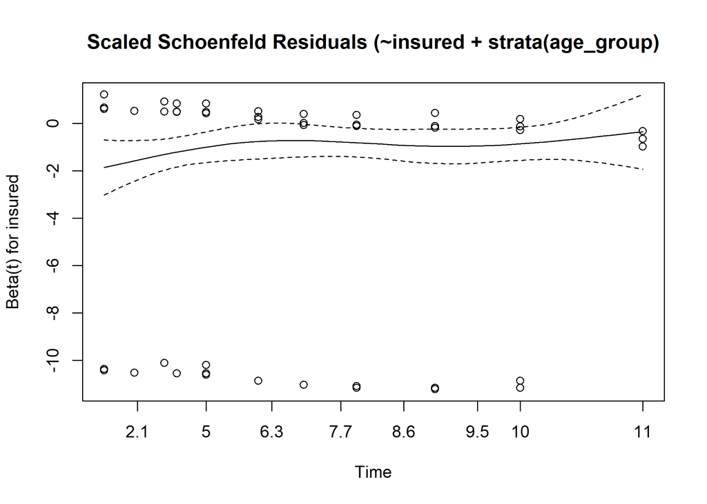

We assess the no-interaction assumption for the age strata and insurance status. The coefficient estimates of separate models by age strata do not appear greatly different. We confirm that there is no significant interaction between the strata and insurance status with a Chi-Squared test of model difference with 2 degrees of freedom.

```
## insuredYes
##  -1.024484
```

```
## insuredYes
##  -1.132176
```

```
## insuredYes
## -0.5306798
```

```
## Call:
## coxph(formula = surv_obj ~ insured * age_group - age_group +
##     strata(age_group), data = surv.df)
##
##                              coef exp(coef) se(coef)      z        p
## insuredYes                -1.0245    0.3590   0.3063 -3.345 0.000824
## insuredNo:age_group46_49   0.1077    1.1137   0.4341  0.248 0.804077
## insuredYes:age_group46_49      NA        NA   0.0000     NA       NA
## insuredNo:age_group50_53  -0.4938    0.6103   0.6077 -0.813 0.416460
## insuredYes:age_group50_53      NA        NA   0.0000     NA       NA
##
## Likelihood ratio test=19.72  on 3 df, p=0.0001943
## n= 2686, number of events= 274
```

```
## Analysis of Deviance Table
##  Cox model: response is  surv_obj
##  Model 1: ~ insured * age_group - age_group + strata(age_group)
##  Model 2: ~ insured + strata(age_group)
##    loglik  Chisq Df P(>|Chi|)
## 1 -1758.4
## 2 -1759.0 1.0848  2    0.5814
```

With all model assumptions met, we interpret the model. The hazard ratio for those with insurance compared to those without insurance is 0.375 which appears significant at $\alpha = 0.001$ ($p < 0.0001$), suggesting that risk for diabetes is 62.5% lower for insured than for uninsured American women.

## Stratified Cox Model with Insurance Status, Race, BMI, and Household Income

```
## Call:
## coxph(formula = surv_obj ~ insured + race + income + bmi_group +
##     strata(age_group), data = surv.df)
##
##   n= 2686, number of events= 274
##
##                                   coef exp(coef) se(coef)      z Pr(>|z|)
## insuredYes                     -0.2999    0.7409   0.2245 -1.336 0.181570
## raceBlack/African American      0.3692    1.4465   0.1418  2.602 0.009256 **
## raceChinese/Chinese American    0.5409    1.7175   0.2612  2.071 0.038381 *
## raceJapanese/Japanese American  0.5488    1.7311   0.2610  2.103 0.035482 *
## raceHispanic                    1.0069    2.7370   0.2851  3.531 0.000413 ***
## income<20                       0.5960    1.8148   0.1867  3.193 0.001410 **
## income20-49                     0.2195    1.2455   0.1471  1.493 0.135548
## income100+                     -0.6725    0.5104   0.2753 -2.443 0.014583 *
## bmi_group30_40                  1.2991    3.6661   0.1535  8.464  < 2e-16 ***
## bmi_group40+                    1.9361    6.9317   0.1787 10.837  < 2e-16 ***
## ---
## Signif. codes:  0 '***' 0.001 '**' 0.01 '*' 0.05 '.' 0.1 ' ' 1
##
##                                exp(coef) exp(-coef) lower .95 upper .95
## insuredYes                        0.7409     1.3497    0.4772    1.1504
## raceBlack/African American        1.4465     0.6913    1.0954    1.9101
## raceChinese/Chinese American      1.7175     0.5823    1.0294    2.8656
## raceJapanese/Japanese American    1.7311     0.5777    1.0380    2.8870
## raceHispanic                      2.7370     0.3654    1.5653    4.7858
## income<20                         1.8148     0.5510    1.2587    2.6164
## income20-49                       1.2455     0.8029    0.9336    1.6617
## income100+                        0.5104     1.9591    0.2976    0.8756
## bmi_group30_40                    3.6661     0.2728    2.7136    4.9528
## bmi_group40+                      6.9317     0.1443    4.8840    9.8381
##
## Concordance= 0.783  (se = 0.014 )
## Likelihood ratio test= 249.5  on 10 df,   p=<2e-16
## Wald test            = 249.6  on 10 df,   p=<2e-16
## Score (logrank) test = 323.9  on 10 df,   p=<2e-16
```

We assess the proportional hazards assumption for the above model using a Goodness-of-Fit test based on the Schoenfeld residuals (Grambsch & Therneau, 1994). All p-values are greater than $\alpha = 0.05$, so the proportional hazards assumption is met for the model.

```
##            chisq df     p
## insured    0.193  1 0.660
## race       3.414  4 0.491
## income     7.299  3 0.063
## bmi_group  2.248  2 0.325
## GLOBAL    10.439 10 0.403
```

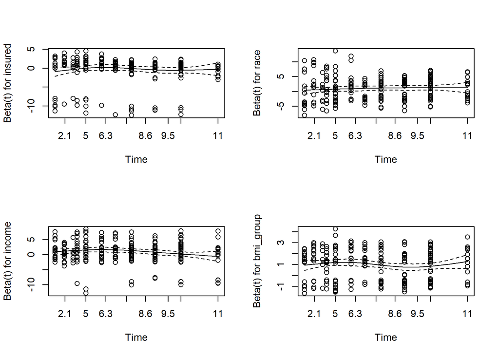

Fitting separate proportional hazards models for each strata, it appears that the estimated coefficients are similar. We fit a larger model that includes the interaction between the strata and the covariates, and, using a Chi-squared test for model differences between the larger model and the previously estimated model, we evaluate the no-interaction assumption for the strata and the covariates. We find no significant interaction between the strata and the covariates. The no-interaction assumption is met.

```
##                     insuredYes     raceBlack/African American
##                     -0.4136639                      0.2536268
##   raceChinese/Chinese American raceJapanese/Japanese American
##                      0.5382627                      0.6425530
##                   raceHispanic                      income<20
##                      0.9426894                      0.5379860
##                    income20-49                     income100+
##                      0.2519268                     -1.5268428
##                 bmi_group30_40                   bmi_group40+
##                      1.2920227                      2.0143054
```

```
##                     insuredYes     raceBlack/African American
##                     -0.2289073                      0.3029919
##   raceChinese/Chinese American raceJapanese/Japanese American
##                      0.3162251                      0.2299793
##                   raceHispanic                      income<20
##                      0.8082113                      0.8805006
##                    income20-49                     income100+
##                      0.4132505                     -0.1850171
##                 bmi_group30_40                   bmi_group40+
##                      1.6270242                      2.0151623
```

```
##                     insuredYes     raceBlack/African American
##                      0.1308036                      0.9499241
##   raceChinese/Chinese American raceJapanese/Japanese American
##                      1.0105203                      1.0113319
##                   raceHispanic                      income<20
##                      1.9234576                      0.3087611
##                    income20-49                     income100+
##                     -0.2165819                     -1.0190396
##                 bmi_group30_40                   bmi_group40+
##                      0.2365627                      1.4038967
```

```
## Analysis of Deviance Table
##  Cox model: response is  surv_obj
##  Model 1: ~ (insured + race + income + bmi_group) * age_group - age_group + strata(age_group)
##  Model 2: ~ insured + race + income + bmi_group + strata(age_group)
##    loglik  Chisq Df P(>|Chi|)
## 1 -1632.4
## 2 -1643.5 22.223 20    0.3285
```

# Stratified Cox Model with Insurance Status, Race, and BMI

To investigate which factor adjustment makes the effect of insurance status insignificant, we build separate stratified Cox models with race and one of the other factors: race, household income, or BMI group. From the models below, we see that adjusting for baseline household income makes the effect of insurance status insignificant.

**CPH Model for Insurance and Race**

```
## Call:
## coxph(formula = surv_obj ~ insured + race + strata(age_group),
##     data = surv.df)
##
##                                    coef exp(coef) se(coef)      z        p
## insuredYes                     -0.63970   0.52745  0.21821 -2.932  0.00337
## raceBlack/African American      0.86540   2.37595  0.13677  6.327 2.49e-10
## raceChinese/Chinese American    0.00765   1.00768  0.25069  0.031  0.97565
## raceJapanese/Japanese American -0.09013   0.91381  0.25054 -0.360  0.71903
## raceHispanic                    1.36045   3.89794  0.27823  4.890 1.01e-06
##
## Likelihood ratio test=76.11  on 5 df, p=5.466e-15
## n= 2686, number of events= 274
```

```
##         chisq df    p
## insured 0.185  1 0.67
## race    3.490  4 0.48
## GLOBAL  3.629  5 0.60
```

```
## Analysis of Deviance Table
##  Cox model: response is surv_obj
## Terms added sequentially (first to last)
##
##          loglik  Chisq Df Pr(>|Chi|)
## NULL    -1768.3
## insured -1759.0 18.632  1  1.585e-05 ***
## race    -1730.2 57.474  4  9.840e-12 ***
## ---
## Signif. codes:  0 '***' 0.001 '**' 0.01 '*' 0.05 '.' 0.1 ' ' 1
```

```
## Analysis of Deviance Table
##  Cox model: response is  surv_obj
##  Model 1: ~ (insured + race) * age_group - age_group + strata(age_group)
##  Model 2: ~ insured + race + strata(age_group)
##    loglik Chisq Df P(>|Chi|)
## 1 -1725.1
## 2 -1730.2 10.29 10    0.4154
```

**CPH Model for Insurance and Baseline Household Income**

```
## Call:
## coxph(formula = surv_obj ~ insured + income + strata(age_group),
##     data = surv.df)
##
##                coef exp(coef) se(coef)      z        p
## insuredYes  -0.3397    0.7120   0.2177 -1.560 0.118689
## income<20    1.1547    3.1731   0.1764  6.547 5.86e-11
## income20-49  0.3939    1.4827   0.1451  2.714 0.006648
## income100+  -0.9179    0.3994   0.2727 -3.366 0.000763
##
## Likelihood ratio test=90.52  on 4 df, p=< 2.2e-16
## n= 2686, number of events= 274
```

```
##         chisq df     p
## insured  1.28  1 0.257
## income   9.18  3 0.027
## GLOBAL   9.50  4 0.050
```

```
## Call:
## coxph(formula = surv_obj ~ insured + strata(income) + strata(age_group),
##     data = surv.df)
##
##               coef exp(coef) se(coef)     z     p
## insuredYes -0.3115    0.7324   0.2208 -1.41 0.158
##
## Likelihood ratio test=1.88  on 1 df, p=0.1701
## n= 2686, number of events= 274
```

```
##         chisq df    p
## insured 0.341  1 0.56
## GLOBAL  0.341  1 0.56
```

```
## Analysis of Deviance Table
##  Cox model: response is  surv_obj
##  Model 1: ~ insured + strata(income) + strata(age_group)
##  Model 2: ~ insured * age_group + insured * income - age_group - income + strata(age_group) + strata(income)
##    loglik  Chisq Df P(>|Chi|)
## 1 -1393.4
## 2 -1390.7 5.4508  5    0.3634
```

**CPH Model for Insurance and BMI Group**

```
## Call:
## coxph(formula = surv_obj ~ insured + bmi_group + strata(age_group),
##     data = surv.df)
##
##                   coef exp(coef) se(coef)      z        p
## insuredYes     -0.7725    0.4619   0.2014 -3.836 0.000125
## bmi_group30_40  1.3740    3.9510   0.1389  9.895  < 2e-16
## bmi_group40+    2.0768    7.9790   0.1626 12.770  < 2e-16
##
## Likelihood ratio test=199.3  on 3 df, p=< 2.2e-16
## n= 2686, number of events= 274
```

```
##           chisq df    p
## insured    1.42  1 0.23
## bmi_group  2.16  2 0.34
## GLOBAL     3.39  3 0.34
```

```
## Analysis of Deviance Table
##  Cox model: response is  surv_obj
##  Model 1: ~ insured + bmi_group + strata(age_group)
##  Model 2: ~ (insured + bmi_group) * age_group - age_group + strata(age_group)
##    loglik  Chisq Df P(>|Chi|)
## 1 -1668.6
## 2 -1664.0 9.2969  6    0.1576
```

_CPH Model for Insurance, Race, and BMI Group__

```
## Call:
## coxph(formula = surv_obj ~ insured + bmi_group + race + strata(age_group),
##     data = surv.df)
##
##   n= 2686, number of events= 274
##
##                                   coef exp(coef) se(coef)      z Pr(>|z|)
## insuredYes                     -0.5427    0.5812   0.2175 -2.495 0.012586 *
## bmi_group30_40                  1.3670    3.9237   0.1527  8.954  < 2e-16 ***
## bmi_group40+                    2.0709    7.9317   0.1761 11.757  < 2e-16 ***
## raceBlack/African American      0.5019    1.6519   0.1392  3.606 0.000311 ***
## raceChinese/Chinese American    0.5777    1.7819   0.2603  2.219 0.026497 *
## raceJapanese/Japanese American  0.4690    1.5985   0.2594  1.808 0.070560 .
## raceHispanic                    1.2898    3.6320   0.2784  4.632 3.62e-06 ***
## ---
## Signif. codes:  0 '***' 0.001 '**' 0.01 '*' 0.05 '.' 0.1 ' ' 1
##
##                                exp(coef) exp(-coef) lower .95 upper .95
## insuredYes                        0.5812     1.7206    0.3795    0.8901
## bmi_group30_40                    3.9237     0.2549    2.9089    5.2924
## bmi_group40+                      7.9317     0.1261    5.6161   11.2021
## raceBlack/African American        1.6519     0.6054    1.2575    2.1701
## raceChinese/Chinese American      1.7819     0.5612    1.0697    2.9681
## raceJapanese/Japanese American    1.5985     0.6256    0.9614    2.6576
## raceHispanic                      3.6320     0.2753    2.1044    6.2683
##
## Concordance= 0.766  (se = 0.015 )
## Likelihood ratio test= 227.6  on 7 df,   p=<2e-16
## Wald test            = 236.4  on 7 df,   p=<2e-16
## Score (logrank) test = 301.2  on 7 df,   p=<2e-16
```

First, we assess the proportional hazards assumption for the above model using a Goodness-of-Fit test based on the Schoenfeld residuals (Grambsch & Therneau, 1994). The proportional hazards assumption is met for all factors since there are no significant p-values at $\alpha = 0.05$.

```
##           chisq df    p
## insured   0.108  1 0.74
## bmi_group 2.006  2 0.37
## race      3.551  4 0.47
## GLOBAL    4.477  7 0.72
```

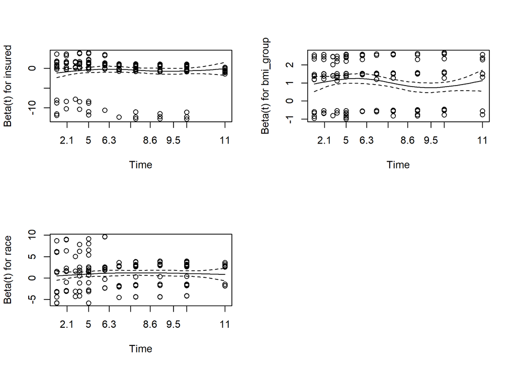

We assess the no-interaction assumption between the strata and the covariates using a Chi-squared test of model difference with 14 degrees of freedom. We find no significant interaction between the strata and the covariates, insurance, race, and BMI group.

```
## Analysis of Deviance Table
##  Cox model: response is  surv_obj
##  Model 1: ~ (insured + race + bmi_group) * age_group - age_group + strata(age_group)
##  Model 2: ~ insured + bmi_group + race + strata(age_group)
##    loglik  Chisq Df P(>|Chi|)
## 1 -1646.7
## 2 -1654.5 15.669 14     0.334
```